# Visualizing Ford GoBike System Data (Bay Wheels)

# Introduction

> Our investigation is focused on how long, how far a and when people are using Ford GoBikes.

> Bay Wheels is a regional public bicycle sharing system in the San Francisco Bay Area, California operated by Motivate in a partnership with the Metropolitan Transportation Commission and the Bay Area Air Quality Management District. Bay Wheels is the first regional and large-scale bicycle sharing system deployed in California and on the West Coast of the United States. It was established as Bay Area Bike Share in August 2013. As of January 2018, the Bay Wheels system had over 2,600 bicycles in 262 stations across San Francisco, East Bay and San Jose. On June 28, 2017, the system officially re-launched as Ford GoBike in a partnership with Ford Motor Company. After Motivate's acquisition by Lyft, the system was subsequently renamed to Bay Wheels in June 2019. The system is expected to expand to 7,000 bicycles around 540 stations in San Francisco, Oakland, Berkeley, Emeryville, and San Jose.

```python
import numpy as np
import pandas as pd
import matplotlib.pyplot as plt
import seaborn as sb
import geopy.distance

%matplotlib inline
```

```python
df = pd.read_csv('df_ford_clean.csv')
df.head()
```

|  | duration_sec | start_time | end_time | start_station_latitude | start_station_longitude | end_station_latitude | end_station_longitude | bike_id | user_type | rental_access_method | day_start | day_end | month_start | month_end | hour_start | hour_end | duration_min | distance_km |
| --- | --- | --- | --- | --- | --- | --- | --- | --- | --- | --- | --- | --- | --- | --- | --- | --- | --- | --- |
| 0 | 35187 | 2020-03-31 20:42:10.079 | 2020-04-01 06:28:37.844 | 37.804648 | -122.402087 | 37.789677 | -122.390428 | 10982 | Customer | NaN | Tuesday | Wednesday | 3 | 4 | 20 | 6 | 586.4 | 1.95 |
| 1 | 14568 | 2020-03-31 22:45:25.501 | 2020-04-01 02:48:13.773 | 37.778650 | -122.418230 | 37.787327 | -122.413278 | 12617 | Customer | NaN | Tuesday | Wednesday | 3 | 4 | 22 | 2 | 242.8 | 1.06 |
| 2 | 35990 | 2020-03-31 15:08:22.331 | 2020-04-01 01:08:12.990 | 37.355030 | -121.904436 | 37.361867 | -121.909315 | 12812 | Customer | NaN | Tuesday | Wednesday | 3 | 4 | 15 | 1 | 599.8 | 0.87 |
| 3 | 1068 | 2020-03-31 23:55:00.426 | 2020-04-01 00:12:49.020 | 37.781468 | -122.458806 | 37.763015 | -122.426497 | 12955 | Customer | NaN | Tuesday | Wednesday | 3 | 4 | 23 | 0 | 17.8 | 3.51 |
| 4 | 3300 | 2020-03-31 23:00:55.641 | 2020-03-31 23:55:56.611 | 37.804770 | -122.403234 | 37.789677 | -122.390428 | 13050 | Customer | NaN | Tuesday | Tuesday | 3 | 3 | 23 | 23 | 55.0 | 2.02 |

## Bikes usage by days

> The most popular day for biking is Wednesday. It's the middle of the week and everybody goes to work. In the first days of the week Monday and Tuesday right after the weekend are people lazy so better stay home or go to work by car, tram and so on. During a weekend many people don't go to work and using the bicycle is going down.

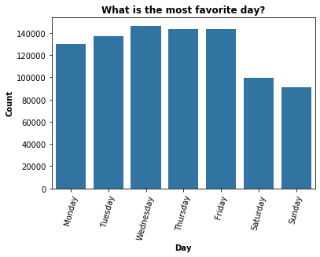

```python
base_color = sb.color_palette()[0]
day = ['Monday', 'Tuesday', 'Wednesday', 'Thursday', 'Friday', 'Saturday', 'Sunday']
sb.countplot(data = df, x = 'day_start', color = base_color, order = day)
plt.title('What is the most favorite day?', weight = 'bold')
plt.xlabel('Day', weight = 'bold')
plt.ylabel('Count', weight = 'bold')
plt.xticks(rotation = 75);
```

## Bikes usage by months

> We check data for months in 2020. It is really nice surprise because during a February 2020 we have the highest number. February is still and we have much more rented bikes than in March.

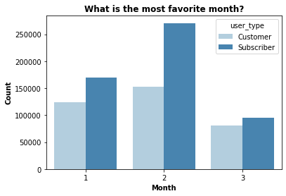

```python
sb.countplot(data = df, x = 'month_start', hue = 'user_type', palette = 'Blues')
plt.title('What is the most favorite month?', weight = 'bold')
plt.xlabel('Month', weight = 'bold')
plt.ylabel('Count', weight = 'bold');
```

> Nobody likes it on the bike during a night. You don't have enough light, everything is scary and if you are drunk it is hard to coordinate. We can see the same data on the graph. In the morning everybody goes to work and usage is almost on the peak, but some people are still sleepy and that's the reason why the highest peak is between 5-6 pm.

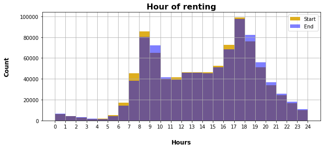

```python
bin_edges = np.arange(0, 25)
ax = df['hour_start'].hist(alpha=0.9, bins = bin_edges, figsize=(10,4),label = 'Start', color='#DBA506')
ay = df['hour_end'].hist(alpha=0.5, bins = bin_edges,  figsize=(10,4), label = 'End', color='blue')
ax.set_title('Hour of renting', weight='bold', size=16)
ax.set_xlabel('Hours', labelpad=20, weight='bold', size=12)
ax.set_ylabel('Count', labelpad=20, weight='bold', size=12)
plt.xticks(np.arange(0, 25, 1))
plt.legend();
```

## How far you get?

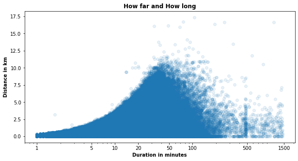

```python
plt.figure(figsize = [10, 5])
plt.scatter(data = df, x = 'duration_min', y = 'distance_km', alpha = 1/10)
plt.title('How far and How long', weight = 'bold')
plt.xlabel('Duration in minutes', weight = 'bold')
plt.ylabel('Distance in km', weight = 'bold')
plt.xscale('log');
plt.xticks([1, 5, 10, 20, 50, 100, 500, 1500], [1, 5, 10, 20, 50, 100, 500, 1500]);
```

## Who is bigger rider Customer or Subscriber

> When we look at them it looks like we have tie, but customer ride on bike longer time. There is good visualization Monday and Tuesday. Subscriber drive less minutes compare to Customers. During a weekend we have also more Customers.

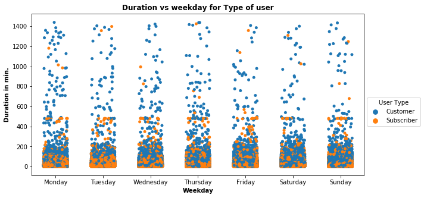

```python
plt.figure(figsize = [10, 5])
ax = sb.stripplot(data = df, x = 'day_start', y = 'duration_min', hue = 'user_type', jitter = 0.25, order = day)
ax.legend(loc = 8, ncol = 3, framealpha = 1, title = 'user_type')
plt.xlabel('Weekday', weight = 'bold')
plt.ylabel('Duration in min.', weight = 'bold')
plt.title('Duration vs weekday for Type of user', weight = 'bold')
plt.legend(bbox_to_anchor = (1, 0.5),title = 'User Type');
```

## When is the right time to be a reach if you have only bike?

> The most popular month for renting a bike was February and the most popular hour is 5 pm. So if you have a bike and you wanna rent it. Do it in February at 5 pm more than 40 thousand rents were during that time. Also if you are an early bird, you can do it the same month at 8 am.

[figure not shown]

```python
plt.subplots(figsize=(15, 7))
df_heat_map = df.groupby(['month_start', 'hour_start'])['bike_id'].size().reset_index();
df_heat_map = df_heat_map.pivot('month_start', 'hour_start', 'bike_id')
heat_map = sb.heatmap(df_heat_map, cmap = 'viridis_r', linewidths=.5)

plt.title("Renting Bike", weight = 'bold')
plt.xlabel('Month', weight = 'bold')
plt.ylabel('Weekday', weight = 'bold');
plt.show()
```